# Lecture 3

20 January 2021

## Structure

1. Distance
2. k-Nearest neighbourhood
3. Recommendation system

## Distance

**What is a distance?**

## What is a distance? (i)

Manhattan

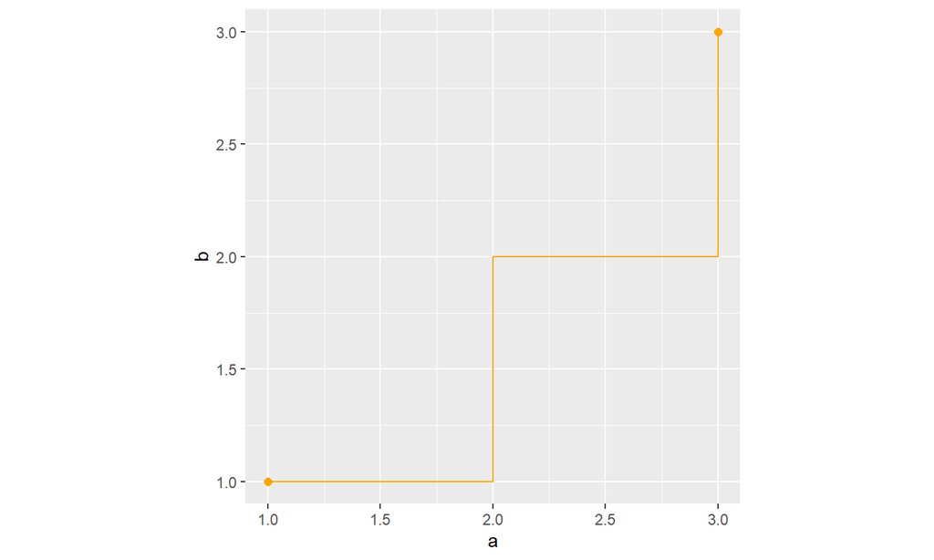

## What is a distance? (ii)

Euclidean

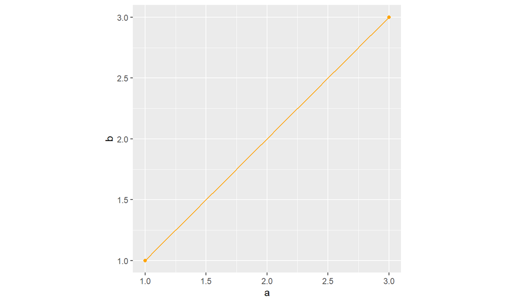

## What is a distance? (iii)

Hamming distance \[H(x,y) = \sum_{i=1}^{n} 1_{x_{i} \ne y_{i}}\]

## How about “distance” in mixed data?

- similarity
- scale dummies OR
- Gower metric (scaled distances)

\[G(x,y) = \frac{1}{p} \sum_{n=1}^{p} \frac{|x_{n} - y_{n}|}{range(n)} \]

## k-Nearest neighbourhoods

## What does it do?

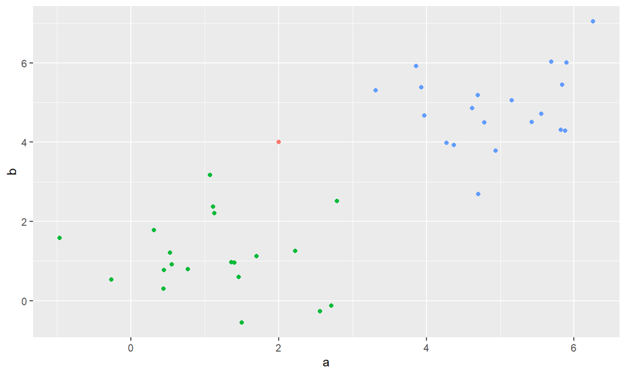

## Closest point?

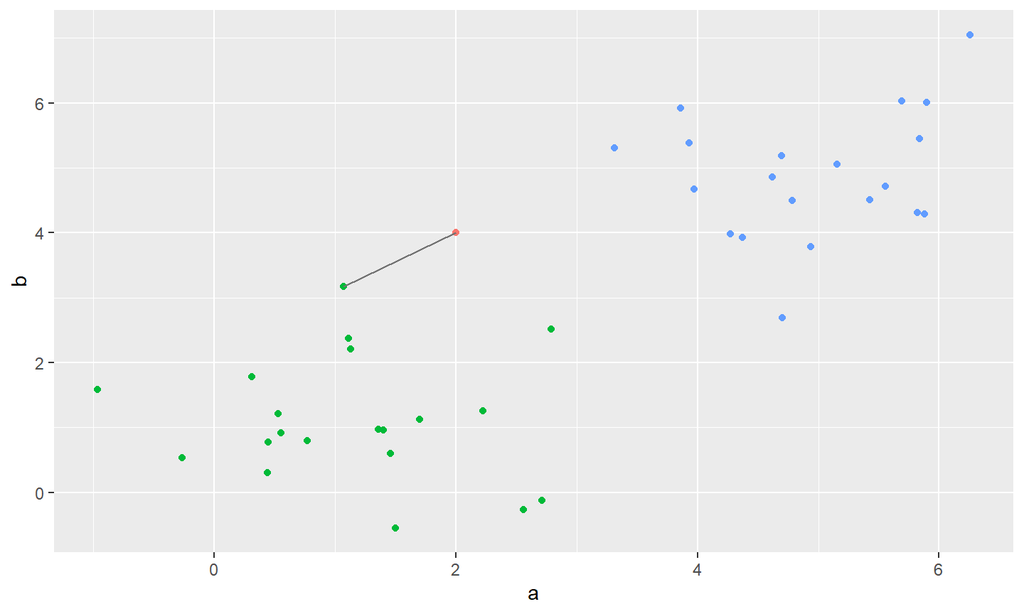

## Two closest points?

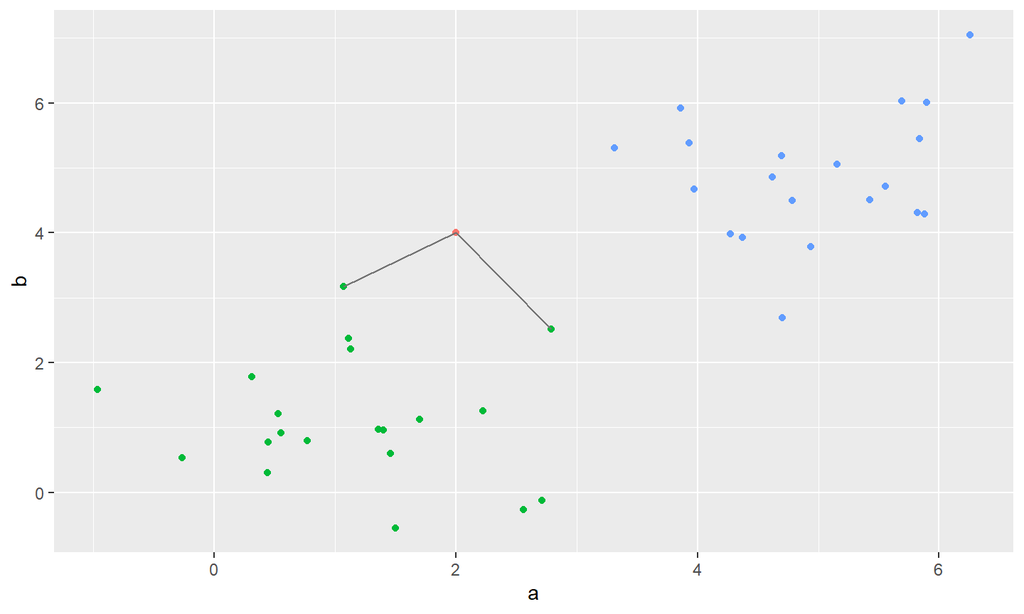

## K closest points?

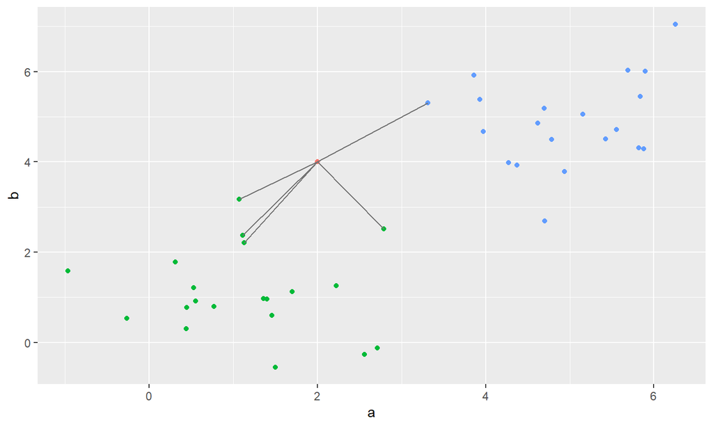

## Distance weights

\[support(class) = \sum_{i=1}^{k} \frac {1}{dist_{i}}\]

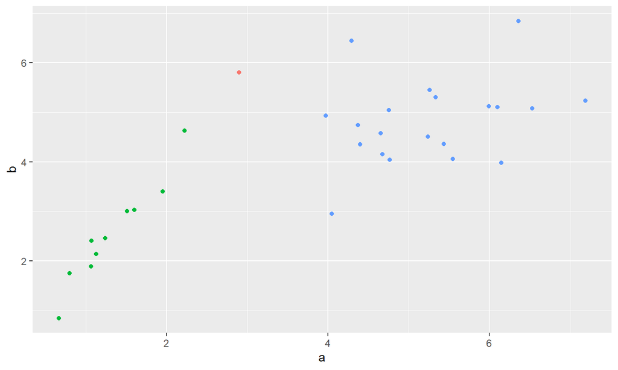

## kNN algorithm summary

- classic implementation in R: “class::knn”
- *for each unlabeled point*
  - *find k nearest labeled points*
  - *assign weighted majority vote class*
- greedy greedy algorithm
- lazy learning
- used for:
  - recomender systems
  - customer churn

## Recommender Systems

[figure not shown]

- what do those companies have in common?
- **RECOMMENDATIONS!**

## How to recommend?

- popularity
- collaborative
- content

## Datasets

- collection of users “rating” a product (*always*)
  - actual ratings
  - spotify’s
  - length watched
  - (un)skipped
- collection of product descriptions (features) (*content*)
  - topic / genre
  - actors
  - other properties

## Popularity

- recommend the most popular products
- good start, insufficient on it’s own

## Content

- find a product very similar to what the user likes
- completely dependent on products properties data
- classification problem (let’s use kNN)

## Collaborative

- no content information!
- user - user
  - similar consumers choices
  - find similar customers and recommend their favourites
- item - item
  - similar items
  - find similar items (often positively rated together)

## Collaborative - how do we do that?

- incidence matrix

```
##    m1 m2 m3 m4
## u1  0  1  1  1
## u2  0  0  1  1
## u3  0  0  0  1
## u4  1  0  0  0
## u5  0  0  0  1
```

## Collaborative - how we do that? (ii)

```r
M %*% t(M)
```

```
##    u1 u2 u3 u4 u5
## u1  3  2  1  0  1
## u2  2  2  1  0  1
## u3  1  1  1  0  1
## u4  0  0  0  1  0
## u5  1  1  1  0  1
```

```r
t(M) %*% M
```

```
##    m1 m2 m3 m4
## m1  1  0  0  0
## m2  0  1  1  1
## m3  0  1  2  2
## m4  0  1  2  4
```